# ISYE6414 - Midterm Exam 1 - Open Book Section (R) - Part 2

## Instructions

This Jupyter notebook file includes the questions, the empty code chunk sections for your code, and the text blocks for your responses. Answer the questions below by completing this Jupyter notebook file. You may make slight adjustments to get the file to knit/convert but otherwise keep the formatting the same. Once you've finished answering the questions, submit your responses in a single knitted file as *HTML* only.

There are 10 questions total, each worth between 3-10 points. Partial credit may be given if your code is correct but your conclusion is incorrect or vice versa.

*Next Steps:*

1. Save this .ipynb file in your R working directory - the same directory where you will download the "bikerental.csv" data file into. Having both files in the same directory will help in reading the .csv file.
2. Read the question and create the R code necessary within the code chunk section immediately below each question. Knitting this file will generate the output and insert it into the section below the code chunk.
3. Type your answer to the questions in the text block provided immediately after the response prompt.
4. Once you've finished answering all questions, knit this file and submit the knitted file as *HTML* on Canvas.

### Mock Example Question

This will be the exam question - each question is already copied from Canvas and inserted into individual text blocks below, *you do not need to copy/paste the questions from the online Canvas exam.*

```r
# Example code chunk area. Enter your code below the comment`
```

**Mock Response to Example Question**: This is the section where you type your written answers to the question. Depending on the question asked, your typed response may be a number, a list of variables, a few sentences, or a combination of these elements.

**Ready? Let's begin. We wish you the best of luck!**

**Recommended Packages**

```r
library(car)
```

## Bike Rental Data Analysis

For this exam, you will be building a model to predict the number of bikes rented in a major city in a given hour.

The "bikerental.csv" data set consists of the following variables:

- *Rented.Bike.Count*: number of bikes rented (one hour)
- *Temperature*: Temperature in Celsius
- *Humidity*: Percent humidity
- *Wind.speed*: Wind Speed (m/s)
- *Visibility*: 10m visibility
- *Dew.Point.Temperature*: Dew Point Temperature in Celsius
- *Solar.Radiation*: Solar Radiation measured in (MJ/m^2)
- *Rainfall*: Rainfall in mm (one hour)
- *Snowfall*: Snowfall in cm (one hour)
- *Season*: spring, summer, autumn, winter
- *Holiday*: yes/no
- *Time*: morning, afternoon, evening, night

Read the data and answer the questions below. Assume a significance threshold of 0.05 for hypothesis tests unless stated otherwise.

```r
# Read the data set
bike = read.csv('bikerental.csv',header=TRUE)
#Set variables as categorical
bike$Seasons<-as.factor(bike$Seasons)
bike$Holiday<-as.factor(bike$Holiday)
bike$Time<-as.factor(bike$Time)
head(bike)
```

A data.frame: 6 × 12

|  | Rented.Bike.Count <int> | Temperature <dbl> | Humidity <int> | Wind.speed <dbl> | Visibility <int> | Dew.point.temperature <dbl> | Solar.Radiation <dbl> | Rainfall <dbl> | Snowfall <dbl> | Seasons <fct> | Holiday <fct> | Time <fct> |
| --- | --- | --- | --- | --- | --- | --- | --- | --- | --- | --- | --- | --- |
| 1 | 254 | -5.2 | 37 | 2.2 | 2000 | -17.6 | 0 | 0 | 0 | Winter | no | night |
| 2 | 204 | -5.5 | 38 | 0.8 | 2000 | -17.6 | 0 | 0 | 0 | Winter | no | night |
| 3 | 173 | -6.0 | 39 | 1.0 | 2000 | -17.7 | 0 | 0 | 0 | Winter | no | night |
| 4 | 107 | -6.2 | 40 | 0.9 | 2000 | -17.6 | 0 | 0 | 0 | Winter | no | night |
| 5 | 78 | -6.0 | 36 | 2.3 | 2000 | -18.6 | 0 | 0 | 0 | Winter | no | night |
| 6 | 100 | -6.4 | 37 | 1.5 | 2000 | -18.7 | 0 | 0 | 0 | Winter | no | night |

**Note:** For all of the following questions, treat all variables as quantitative variables except for *Seasons*, *Holiday* and *Time*. They have already been converted to categorical variables in the above code.

### Question 1 - Exploratory Data Analysis of Categorical Variable

Create a boxplot of the response variable *Rented.Bike.Count* and the categorical variable *Time*.

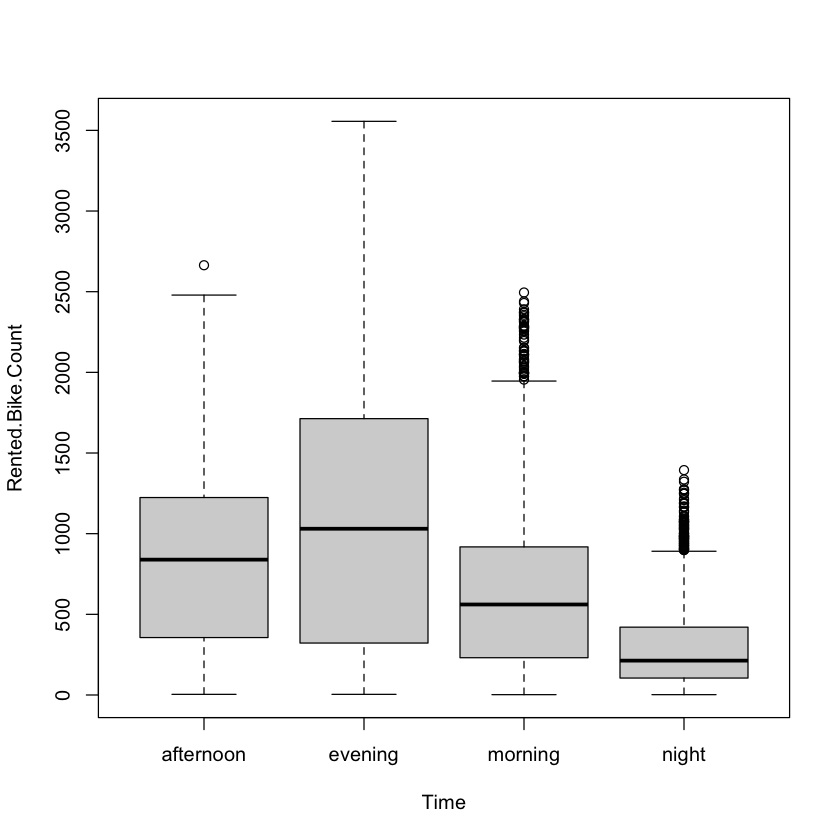

```r
#Code to create boxplot...
boxplot(Rented.Bike.Count ~ Time, data = bike)
```

A) From this plot, do there appear to be any outliers that might require further investigation?

**Response to Question 1A**:

Yes - there are multiple outliers that require further investigation. These include outliers in the afternoon, morning, and night.

B) From this plot, does *Time* appear useful in predicting *Rented.Bike.Count*? Explain how you came to your conclusion.

**Response to Question 1B**:

The time does appear useful as the mean of the count of rented bikes seems to be different depending on time of day. However, further investigation is needed to statistically prove this conclusion.

### Question 2 - ANOVA

Create an ANOVA model called *anovamodel* to compare the mean *Rented.Bike.Count* among the different times of day. Display the corresponding ANOVA table.

```r
#Code to create and display ANOVA table

anovamodel <- aov(Rented.Bike.Count~Time, data=bike)

summary(anovamodel)
```

```
              Df    Sum Sq   Mean Sq F value Pr(>F)
Time           3 7.453e+08 248423374   765.1 <2e-16 ***
Residuals   8461 2.747e+09    324678
---
Signif. codes:  0 ‘***’ 0.001 ‘**’ 0.01 ‘*’ 0.05 ‘.’ 0.1 ‘ ’ 1
```

A) Identify the value of the sum of square treatments (SSTr) from the ANOVA table.

**Response to Question 2A**:

The sum of square treatments is identified as: 7.453e+08.

B) Provide the formula that is used to calculate F-value in the table. Given this value, is the between-group variability greater than the within-group variability? Explain.

**Response to Question 2B**: F-Value = Between Group Variability (MSSTr) / Within-in Group Variability (MSE) = 248423374 / 324678 = 765.1

Yes - the bewteen-group variability is greater than the within-group variability because the F-value is large.

### Question 3 - Test of Equal Means

A) State the null and alternative hypotheses for the test of equal means across different times of day.

**Response to Question 3A**

$H_0$: The mean count of rentals is the same across different times of day.

$H_A$: At least one of the means is different.

B) Do you reject or fail to reject the null hypothesis of the test of equal means at a significance level of $\alpha = 0.05$? Explain your answer using the values from the ANOVA table.

**Response to Question 3B**

We reject the null hypothesis that all of the means are equal because the p-value ($\approx$0) is less than the $\alpha$ value of 0.05.

C) Given your answer in part B, explain what this conclusion means in the context of the problem.

**Response to Question 3C**

At least one of the time periods throughout the day is different than the others in terms of count of bike rentals.

### Question 4 - Pairwise Comparison

Conduct a pairwise comparison of the mean *Rented.Bike.Count* for the different times of day using the Tukey method. Use a 95% confidence level for the comparison.

```r
# Code for pairwise comparison

TukeyHSD(anovamodel)
```

```
  Tukey multiple comparisons of means
    95% family-wise confidence level

Fit: aov(formula = Rented.Bike.Count ~ Time, data = bike)

$Time
                       diff       lwr       upr p adj
evening-afternoon  224.4769  179.4850  269.4688     0
morning-afternoon -241.9825 -286.9797 -196.9852     0
night-afternoon   -575.6928 -620.7166 -530.6689     0
morning-evening   -466.4593 -511.4565 -421.4621     0
night-evening     -800.1696 -845.1935 -755.1458     0
night-morning     -333.7103 -378.7395 -288.6812     0
```

A) According to the pairwise comparison, identify all the pairs that are statistically significantly different. Explain how you came to your conclusion.

**Response to Question 4A**

All of the pairwise comparisons have a p-adj value of 0; therefore, all of the pairs are statistically different using a 95% confidence interval.

B) Provide an interpretation of *diff* in the context of the amount of bike rentals in the morning versus the afternoon. *(Note: provide this interpretation regardless of the means being statistically significantly different/equal)*

**Response to Question 4B**

On average 242 more people rented bikes in the afternoon as compared to the morning.

### Question 5 - Simple Linear Regression

Create a linear regression model, called **lm.temp** with *Rented.Bike.Count* as the response variable and with *Temperature* as the predictor. Include an intercept. Display the summary table for the model.

```r
#Code to fit model and display summary
lm.temp <- lm(Rented.Bike.Count~Temperature, data=bike)
summary(lm.temp)
```

```
Call:
lm(formula = Rented.Bike.Count ~ Temperature, data = bike)

Residuals:
     Min       1Q   Median       3Q      Max
-1075.33  -317.49   -57.92   223.01  2488.52

Coefficients:
            Estimate Std. Error t value Pr(>|t|)
(Intercept) 347.7708     8.3904   41.45   <2e-16 ***
Temperature  29.8633     0.4768   62.63   <2e-16 ***
---
Signif. codes:  0 ‘***’ 0.001 ‘**’ 0.01 ‘*’ 0.05 ‘.’ 0.1 ‘ ’ 1

Residual standard error: 531 on 8463 degrees of freedom
Multiple R-squared:  0.3167,	Adjusted R-squared:  0.3166
F-statistic:  3922 on 1 and 8463 DF,  p-value: < 2.2e-16
```

A) What percentage of the variance in *Rented.Bike.Data* is explained by this model?

**Response to Question 5A**

31.7% of the variation in the response variable *Rented.Bike.Count* is explained by the predictor *Temperature*

B) Provide a brief meaningful interpretation of the estimated regression coefficient for *Temperature*.

**Response to Question 5B**

With each additional degree of temperature the rented bike count increases by 30.

### Question 6 - Residual Analysis

Perform residual analysis on the **lm.temp** model for the 4 assumptions of a simple linear regression model. State whether each assumption holds and why you came to the conclusion.

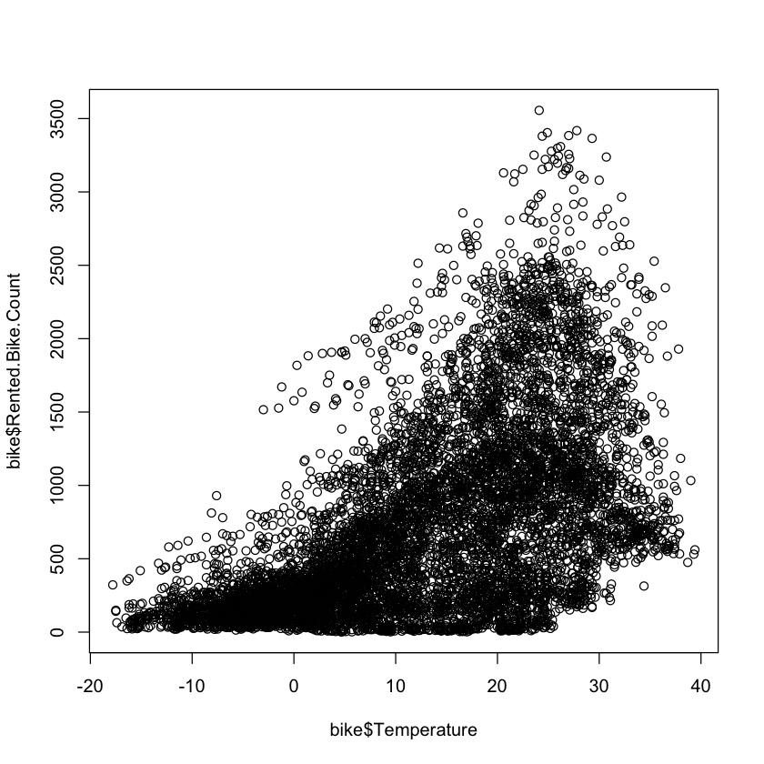

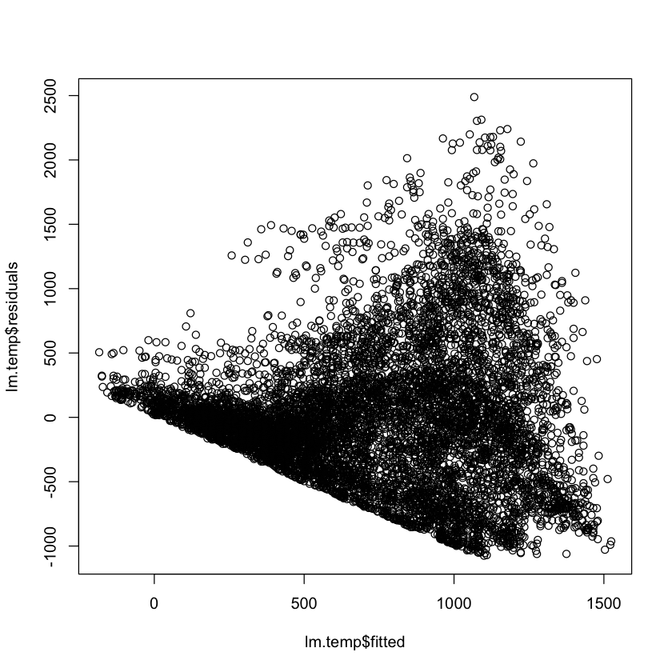

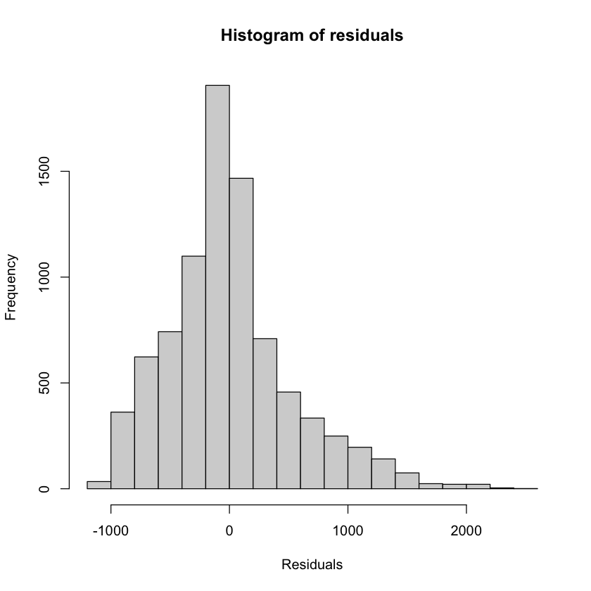

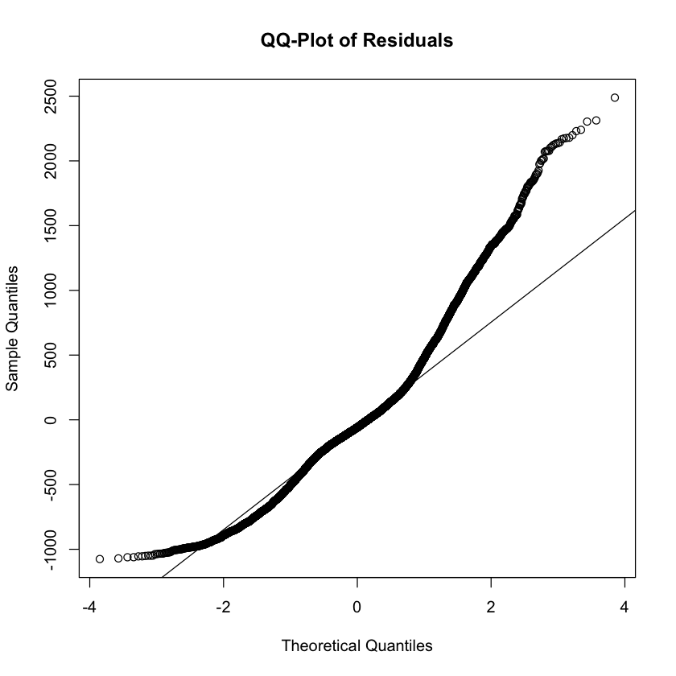

```r
# Code for plots

plot(y=bike$Rented.Bike.Count, x=bike$Temperature)

plot(lm.temp$fitted, lm.temp$residuals)

hist(lm.temp$residuals,main="Histogram of residuals",xlab="Residuals")

qqnorm(lm.temp$residuals, main='QQ-Plot of Residuals')
qqline(lm.temp$residuals)
```

**Response to Question 6**

Linearity Assumption:

Based off the scatterplot the linearity assumption does not hold. A transformation may be necessary in this case.

Constant Variance Assumption and Independence:

Based off the plot of residuals with fitted values, the constant variance assumption does not hold. There does not seem to be clusters of data in the plot; therefore the independence assumption holds.

Normality Assumption:

The histogram has is slightly skewed and the q-q plot displays significant deviations at the tail ends. Therefore the normality assumption does not hold.

### Question 7 - Improving the Fit

A) Find the optimal $\lambda$ value of the Box-Cox transformation for **lm.temp** rounded to the nearest half integer.

0.303

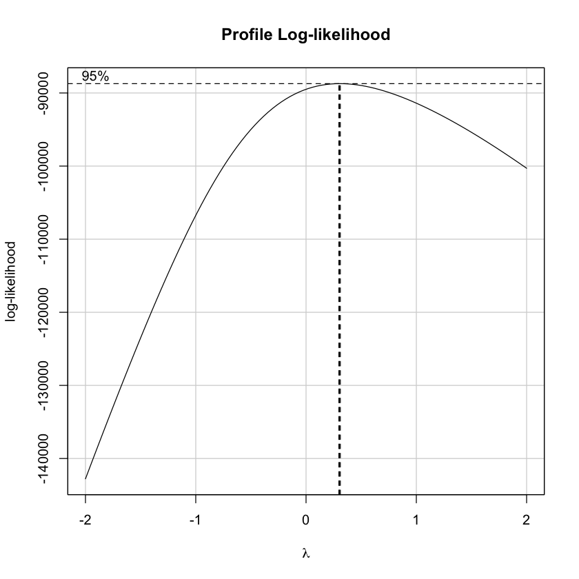

```r
# Code to calculate lambda

bc <- boxCox(lm.temp)

lambda <- bc$x[which.max(bc$y)]
round(lambda, 3)
```

**Response to Question 7A**:

The $\lambda$ value rounded to nearest half integer is 0.5.

B) What transformation of the response variable does this lambda value suggest?

**Response to Question 7B**:

Given a lambda of 0.5, the suggested transformation for the response variable is square root.

C) Create a new model called **lm.temp2** using the suggested transformation on the response variable. Include an intercept and use *Temperature* as the predictor. Display the summary table for the model. Comment on how the R-squared of **lm.temp** compares with the R-squared of **lm.temp2**.

```r
# Code to create new model and display summary
lm.temp2 <- lm(sqrt(Rented.Bike.Count)~Temperature, data=bike)

summary(lm.temp2)
```

```
Call:
lm(formula = sqrt(Rented.Bike.Count) ~ Temperature, data = bike)

Residuals:
     Min       1Q   Median       3Q      Max
-27.2600  -6.0905   0.0672   5.8644  28.7417

Coefficients:
            Estimate Std. Error t value Pr(>|t|)
(Intercept) 16.78632    0.15026  111.72   <2e-16 ***
Temperature  0.58523    0.00854   68.53   <2e-16 ***
---
Signif. codes:  0 ‘***’ 0.001 ‘**’ 0.01 ‘*’ 0.05 ‘.’ 0.1 ‘ ’ 1

Residual standard error: 9.51 on 8463 degrees of freedom
Multiple R-squared:  0.3569,	Adjusted R-squared:  0.3568
F-statistic:  4697 on 1 and 8463 DF,  p-value: < 2.2e-16
```

**Response to Question 7C**:

The R-squarted of the model with a transformed response variable is 0.357. This is greater than the r-squared value of lm.temp (0.317) indicated more variance in the response variable is explained in this model.

D) Re-run the plots from Question 6 which test the assumptions of **constant variance** and **normality**, and comment on whether **these two** assumptions of linear regression hold for **lm.temp2**.

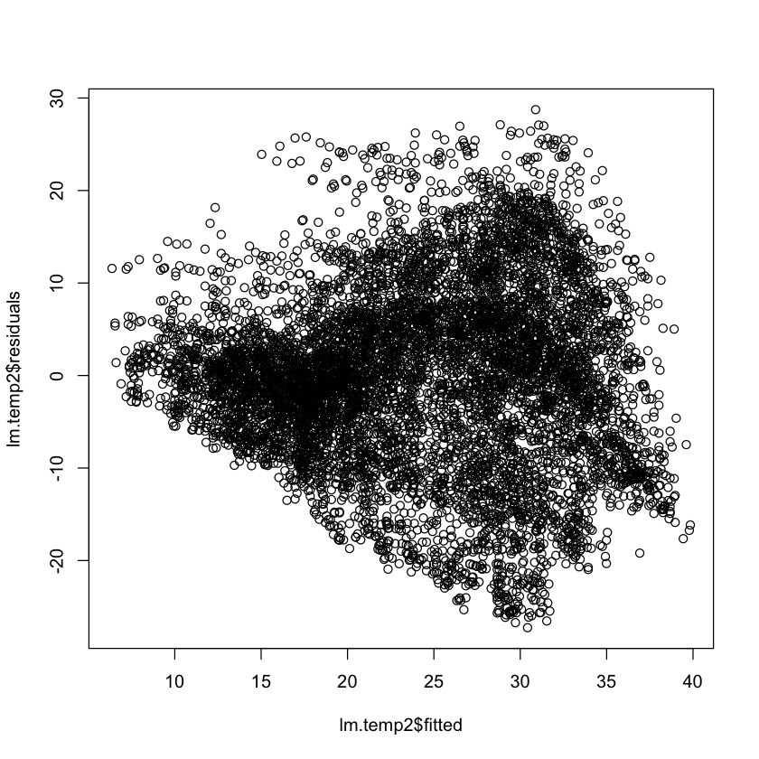

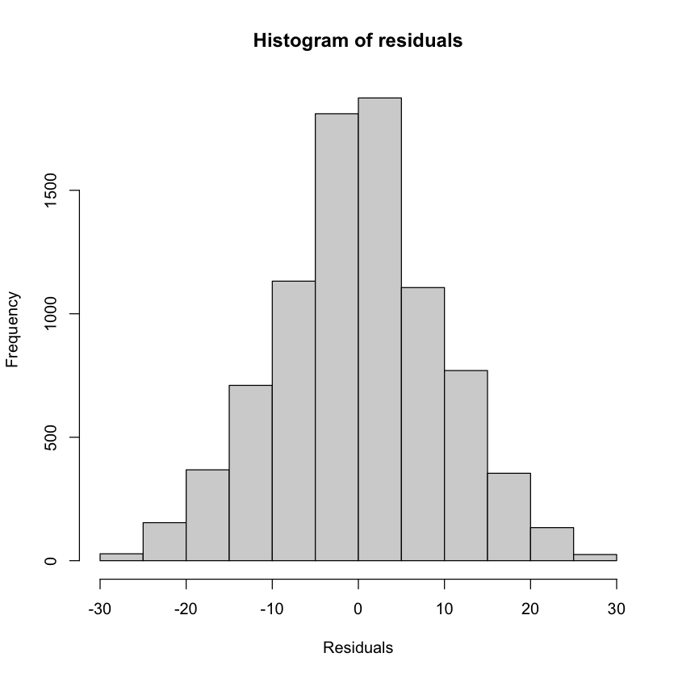

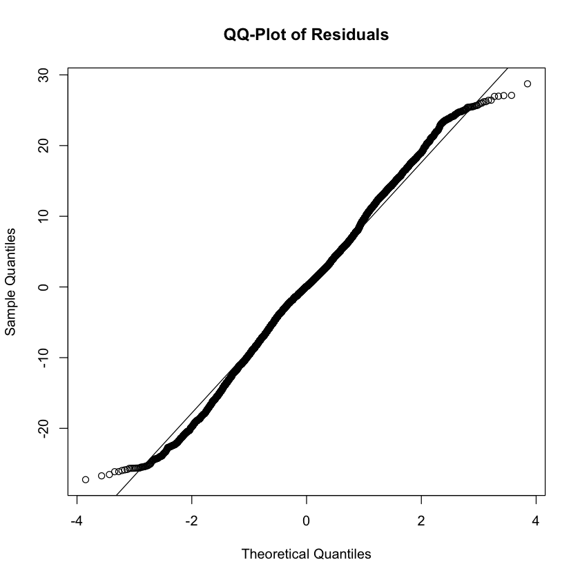

```r
# Code for plots

plot(lm.temp2$fitted, lm.temp2$residuals)

hist(lm.temp2$residuals,main="Histogram of residuals",xlab="Residuals")

qqnorm(lm.temp2$residuals, main='QQ-Plot of Residuals')
qqline(lm.temp2$residuals)
```

**Response to Question 7D**:

Constant Variance:

The variance does seem to increase with an increase in fitted value. While this is much better than the un-transformed data I do not think the constant variance assumption holds.

Normaility:

The data appears to be normal after the transformation. The histogram is normal and there are no significant deviations at the tail ends of the q-q plot.

### Question 8 - Multiple Linear Regression

Create a linear regression model, called **lm.full**, with *Rented.Bike.Count* as the response variable and with **ALL** remaining variables (quantitative and qualitative) as the predictors. Include an intercept Display the summary table for the model. *Note: DO NOT transform any predictor or response variables.*

```r
# Code to create model and display summary
lm.full <- lm(Rented.Bike.Count~., data=bike)
summary(lm.full)
```

```
Call:
lm(formula = Rented.Bike.Count ~ ., data = bike)

Residuals:
     Min       1Q   Median       3Q      Max
-1275.96  -261.82   -54.96   210.36  2127.43

Coefficients:
                        Estimate Std. Error t value Pr(>|t|)
(Intercept)            1.148e+03  9.389e+01  12.227  < 2e-16 ***
Temperature            2.187e+01  3.616e+00   6.049 1.52e-09 ***
Humidity              -9.964e+00  1.007e+00  -9.899  < 2e-16 ***
Wind.speed             2.225e+01  5.100e+00   4.363 1.30e-05 ***
Visibility             3.280e-03  9.792e-03   0.335  0.73763
Dew.point.temperature  6.392e+00  3.765e+00   1.697  0.08965 .
Solar.Radiation       -4.567e+01  9.247e+00  -4.938 8.03e-07 ***
Rainfall              -6.232e+01  4.227e+00 -14.744  < 2e-16 ***
Snowfall               3.400e+01  1.086e+01   3.131  0.00175 **
SeasonsSpring         -1.510e+02  1.374e+01 -10.986  < 2e-16 ***
SeasonsSummer         -1.804e+02  1.693e+01 -10.653  < 2e-16 ***
SeasonsWinter         -3.462e+02  1.933e+01 -17.912  < 2e-16 ***
Holidayyes            -1.258e+02  2.153e+01  -5.842 5.35e-09 ***
Timeevening            3.627e+02  1.700e+01  21.338  < 2e-16 ***
Timemorning            1.651e+01  1.531e+01   1.079  0.28076
Timenight             -2.783e+02  1.793e+01 -15.525  < 2e-16 ***
---
Signif. codes:  0 ‘***’ 0.001 ‘**’ 0.01 ‘*’ 0.05 ‘.’ 0.1 ‘ ’ 1

Residual standard error: 419.2 on 8449 degrees of freedom
Multiple R-squared:  0.5749,	Adjusted R-squared:  0.5742
F-statistic: 761.9 on 15 and 8449 DF,  p-value: < 2.2e-16
```

A) Which coefficients are *not* statistically significant at the 0.05 significance level?

**Response to Question 8A**

Visibility, Dew.point.temperature, and Timemorning

B) Is the model significant overall using an alpha of 0.05? Why/Why not?

**Response to Question 8B**

Yes, the model is significant. The p-value is $\approx$ 0 which is less than 0.05.

### Question 9 - Reduced Model

Create a model named **lm.reduced** with *Rented.Bike.Count* as the response variable and all other variables **except** *Visibility* and *Dew.point.temperature* as predicting variables. Include an intercept. Display the model summary.

```r
# Code to fit and display model

lm.reduced <- lm(Rented.Bike.Count~
                 Temperature+Humidity+Wind.speed+Solar.Radiation+Rainfall+Snowfall+Seasons+Holiday+Time, data=bike)

summary(lm.reduced)
```

```
Call:
lm(formula = Rented.Bike.Count ~ Temperature + Humidity + Wind.speed +
    Solar.Radiation + Rainfall + Snowfall + Seasons + Holiday +
    Time, data = bike)

Residuals:
     Min       1Q   Median       3Q      Max
-1272.91  -263.43   -54.31   212.62  2128.74

Coefficients:
                 Estimate Std. Error t value Pr(>|t|)
(Intercept)     1014.0718    28.9837  34.988  < 2e-16 ***
Temperature       27.8280     0.8654  32.156  < 2e-16 ***
Humidity          -8.4559     0.3019 -28.008  < 2e-16 ***
Wind.speed        22.3386     5.0732   4.403 1.08e-05 ***
Solar.Radiation  -48.5619     9.0708  -5.354 8.85e-08 ***
Rainfall         -63.1682     4.1988 -15.044  < 2e-16 ***
Snowfall          32.5178    10.8278   3.003  0.00268 **
SeasonsSpring   -153.1911    13.3574 -11.469  < 2e-16 ***
SeasonsSummer   -177.8986    16.8632 -10.549  < 2e-16 ***
SeasonsWinter   -347.8751    19.0008 -18.308  < 2e-16 ***
Holidayyes      -125.4592    21.5315  -5.827 5.86e-09 ***
Timeevening      364.8306    16.9316  21.547  < 2e-16 ***
Timemorning       20.1789    15.1512   1.332  0.18295
Timenight       -275.4562    17.7918 -15.482  < 2e-16 ***
---
Signif. codes:  0 ‘***’ 0.001 ‘**’ 0.01 ‘*’ 0.05 ‘.’ 0.1 ‘ ’ 1

Residual standard error: 419.2 on 8451 degrees of freedom
Multiple R-squared:  0.5748,	Adjusted R-squared:  0.5741
F-statistic: 878.8 on 13 and 8451 DF,  p-value: < 2.2e-16
```

A) Perform a partial F-test on the new model (**lm.reduced**) vs the previous model (**lm.full**), using $\alpha = 0.05$. State the null hypothesis of this test. Do you reject or fail to reject the null hypothesis? Explain your answer given the output.

```r
# Code for partial F-test
anova(lm.reduced,lm.full)
```

A anova: 2 × 6

|  | Res.Df <dbl> | RSS <dbl> | Df <dbl> | Sum of Sq <dbl> | F <dbl> | Pr(>F) <dbl> |
| --- | --- | --- | --- | --- | --- | --- |
| 1 | 8451 | 1484994701 | NA | NA | NA | NA |
| 2 | 8449 | 1484456759 | 2 | 537941.8 | 1.530887 | 0.2164038 |

**Response to Question 9A**

$H_0$: The coefficients of visibility and Dew.point.temperature are equal to 0.

$H_A$: At least one of the coefficients of visibility and Dew.point.temperatures is not equal to 0.

The p-value of the partial F-test is 0.216 which is greater than 0.05. Therefore, we fail to reject the null hypothesis that the coefficients of visibility and Dew.point.temperature are equal to 0.

B) Do the variables *Visibility* and/or *Dew.point.temperature* add statistically significant explanatory power to the model, given all other predictors are included in the model? (yes or no should be sufficient if you fully answered Part A)

**Response to Question 9B**

No

C) Regardless of your answer to 9B), are there any circumstances where we might want to keep variables that do not add statistically significant explanatory/predictive power to the model? Explain your answer.

**Response to Question 9C**

Yes there are cases when we may want to keep these variables. We may be able to use them as controlling variables to reduce bias and capture mroe meaningful results.

### Question 10 - Prediction

Using lm.full model, what is the predicted *Rented.Bike.Count* and corresponding 95% prediction interval for an hour with:

- Temperature = 21 degrees Celsius
- Humidity = 18%
- Wind.speed = 1 m/s
- Visibility = 2000
- Dew.point.temperature = 10%
- Solar.Radiation = 2
- Rainfall = 0
- Snowfall = 0
- Seasons = Spring
- Holiday = no
- Time = morning

```r
# Code for prediction and prediction interval
newData <- bike[1,]
newData["Temperature"] = 21
newData["Humidity"] = 18
newData["Wind.speed"] = 1
newData["Visibility"] = 2000
newData["Dew.point.temperature"] = 10
newData["Solar.Radiation"] = 2
newData["Rainfall"] = 0
newData["Snowfall"] = 0
newData["Seasons"] = "Spring"
newData["Holiday"] = "no"
newData["Time"] = "morning"

predict(lm.full, newData, interval="predict")
```

A matrix: 1 × 3 of type dbl

|  | fit | lwr | upr |
| --- | --- | --- | --- |
| 1 | 1294.902 | 469.8179 | 2119.986 |

**Response to Question 10**

The predicted value is 1295. The lower and upper bounds of the prediction are 470 and 2120, respectively.

**THE END**